# Course Project: Writeup

Anshumaan Bajpai

Wednesday, May 20, 2015

This document is a part of the course project for Practical Machine Learning course on Coursera. The document is prepared in a series form where the steps performed are explained as we go ahead.

## Aim

In this project, our goal is to use data from accelerometers on the belt, forearm, arm, and dumbell of 6 participants. The data is divided into two sections:

```
    - Training Set
    - Testing Set
```

Athletes were asked to perform various exercises correctly and incorrectly. I will use the training set data first to train the model to predict if the actions were performed correctly or not. After the model is ready, it will be used to predict the actions for the testing set.

#### Setting the working directory

```r
library(knitr)
## This section sets the working directory where all the files will be saved
setwd("C:/Users/Anshumaan/Desktop/Notre Dame (abajpai1@nd.edu)/Coursera/Paid/Practical_Machine_Learning/Project")
```

Next up we download the requisite data from the web. We will be downloading the data just once and therefore this section will not be evaluated everytime the code is run.

#### Downloading the data

```r
## Downloading testing data
setInternet2(TRUE)
if (!file.exists("./pml_training.csv")){
        download.file("https://d396qusza40orc.cloudfront.net/predmachlearn/pml-training.csv",
                      "./pml_training.csv")
}
## Dowloading training data
if (!file.exists("./pml_testing.csv")){
        download.file("https://d396qusza40orc.cloudfront.net/predmachlearn/pml-testing.csv",
                      "./pml_testing.csv")
}
```

#### Loading the Data

```r
## Reading the training data
pml_training <- read.csv("./pml_training.csv", header=TRUE, na.strings=c("NA", ""))
## Retaining only the columns that have less than 30% values as NA and then remove rows with NA
pml_training <- pml_training[, colMeans(is.na(pml_training)) < 0.3]
pml_training <- na.omit(pml_training)
pml_training$classe <- as.factor(pml_training$classe)

## Reading the testing data
pml_testing <- read.csv("./pml_testing.csv", header=TRUE, na.strings=c("NA", ""))
## Retaining only the columns that have less than 30% values as NA and then remove rows with NA
pml_testing <- pml_testing[, colMeans(is.na(pml_testing)) < 0.3]
pml_testing <- na.omit(pml_testing)

dim(pml_testing)
```

```
## [1] 20 60
```

```r
dim(pml_training)
```

```
## [1] 19622    60
```

In the above section we load both the data: training as well as testing. For both cases, we have insured that we are only using the variables that are present for all the observations. We do not used the testing set at all for building our model. We see that after doing the initial data process, there are 59 variables that do not have NA’s in it. Just a brief overview of the data using str() function tells us that there are dates and other similar components which would not affect the output but are present in the dataset. So we need to figure out which ones of the variables are critical in predicting the classe of the model.

Looking at the data from the original source, it seems there are 4 sensors with 9 measured values and 4 calculated values for each making it a total of 4 * (9+4) = 52 useful predictors. My plan is to build my model on these 52 predictors. So now we reduce our training and testing sets to the requisite predictors. We do however need to make sure that after reducing the dataset to 60 variables, the column in the pml_training and pml_testing set are same. We do so by comparing the colnames for the two dataset except the last column.

## comparing the two dataset for predictor values

```r
sum(colnames(pml_training[,-ncol(pml_training)]) == colnames(pml_testing[,-ncol(pml_testing)]))  ## Ensuring that the column are same in pml_testing and pml_training datasets.
```

```
## [1] 59
```

Since the above sum is 59 so all the columns in the two datasets are same. Now we subset the two datasets to have only the 52 important variables

## Subsetting the datasets to extract relevant predictors

```r
pml_training <- pml_training[, 8:60]
pml_testing <- pml_testing[, 8:60]
```

In order to estimate the out of sample error, I did cross validation. To do that I have divided pml_training data further into a training and a testing set. The training has been done using random forrest classification method.

## Training the model

```r
library(caret)
inTrain <- createDataPartition(y = pml_training$classe, p = 0.75, list=FALSE)
training <- pml_training[inTrain,]
testing <- pml_training[-inTrain,]

## I am using random forest for the model training
library(randomForest)
modelFit <- randomForest(classe ~ ., data = training) # training the model using randomForest
test_pred <- predict(modelFit, testing) # predicting the class for the test to cross validate the model

## Next up we look at the confusion matrix for the prediction
confusionMatrix(test_pred, testing$classe)
```

```
## Confusion Matrix and Statistics
##
##           Reference
## Prediction    A    B    C    D    E
##          A 1395    6    0    0    0
##          B    0  942    1    0    0
##          C    0    1  854    2    0
##          D    0    0    0  799    5
##          E    0    0    0    3  896
##
## Overall Statistics
##
##                Accuracy : 0.9963
##                  95% CI : (0.9942, 0.9978)
##     No Information Rate : 0.2845
##     P-Value [Acc > NIR] : < 2.2e-16
##
##                   Kappa : 0.9954
##  Mcnemar's Test P-Value : NA
##
## Statistics by Class:
##
##                      Class: A Class: B Class: C Class: D Class: E
## Sensitivity            1.0000   0.9926   0.9988   0.9938   0.9945
## Specificity            0.9983   0.9997   0.9993   0.9988   0.9993
## Pos Pred Value         0.9957   0.9989   0.9965   0.9938   0.9967
## Neg Pred Value         1.0000   0.9982   0.9998   0.9988   0.9988
## Prevalence             0.2845   0.1935   0.1743   0.1639   0.1837
## Detection Rate         0.2845   0.1921   0.1741   0.1629   0.1827
## Detection Prevalence   0.2857   0.1923   0.1748   0.1639   0.1833
## Balanced Accuracy      0.9991   0.9962   0.9990   0.9963   0.9969
```

The results of cross validation using the testing dataset described above are encouraging. We find that our model has accuracy over 99.5%. Hence the out of sample error is very low which indicates that the randomForest method does an excellent job for the case at hand. I am sure it is possible to reduce the number of predictors in the model but even with so many predictors, it seems the model does not overfit and produces reliable results.

Lets look at the predictors in terms of their importance in predicting the class.

## Estimating the important variables

```r
varImp(modelFit)
```

```
##                        Overall
## roll_belt            912.75437
## pitch_belt           544.21278
## yaw_belt             681.21186
## total_accel_belt     171.24433
## gyros_belt_x          71.36020
## gyros_belt_y          85.07554
## gyros_belt_z         218.66198
## accel_belt_x          88.93534
## accel_belt_y          94.53757
## accel_belt_z         279.18383
## magnet_belt_x        192.83404
## magnet_belt_y        304.31150
## magnet_belt_z        314.66712
## roll_arm             240.74271
## pitch_arm            124.41992
## yaw_arm              167.93953
## total_accel_arm       76.53539
## gyros_arm_x          103.48159
## gyros_arm_y          105.49488
## gyros_arm_z           45.53039
## accel_arm_x          170.58882
## accel_arm_y          122.68713
## accel_arm_z           96.02276
## magnet_arm_x         203.50231
## magnet_arm_y         171.85104
## magnet_arm_z         136.73294
## roll_dumbbell        318.53305
## pitch_dumbbell       136.61586
## yaw_dumbbell         189.83023
## total_accel_dumbbell 209.41542
## gyros_dumbbell_x      97.53792
## gyros_dumbbell_y     178.58310
## gyros_dumbbell_z      65.41861
## accel_dumbbell_x     210.80356
## accel_dumbbell_y     324.61991
## accel_dumbbell_z     243.82342
## magnet_dumbbell_x    362.77405
## magnet_dumbbell_y    491.24629
## magnet_dumbbell_z    570.74390
## roll_forearm         456.23856
## pitch_forearm        566.00454
## yaw_forearm          131.47655
## total_accel_forearm   81.70982
## gyros_forearm_x       56.21022
## gyros_forearm_y       98.28729
## gyros_forearm_z       64.41443
## accel_forearm_x      235.01788
## accel_forearm_y      105.73769
## accel_forearm_z      174.30786
## magnet_forearm_x     157.37384
## magnet_forearm_y     171.24141
## magnet_forearm_z     213.31598
```

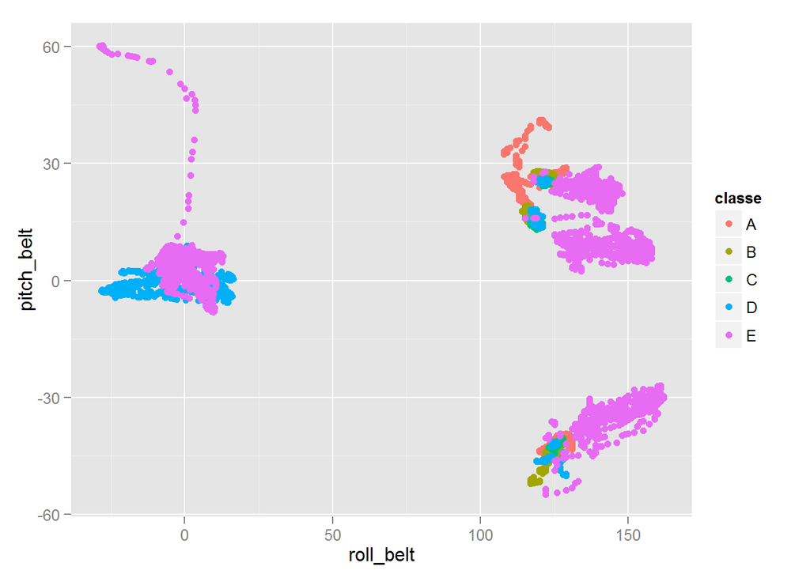

```r
## Next we plot pairs for the important parameters
qplot(roll_belt, pitch_belt, color=classe, data=training)
```

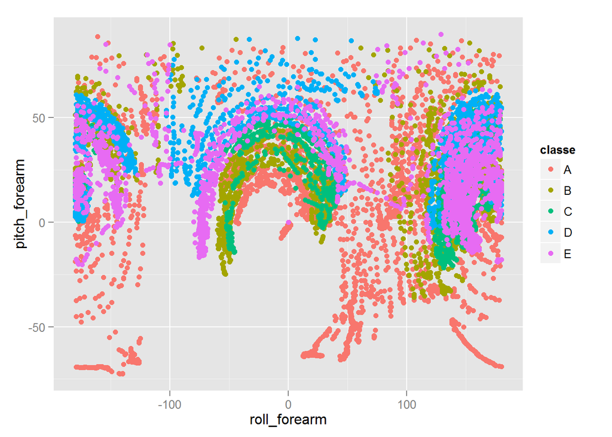

```r
qplot(roll_forearm, pitch_forearm, color=classe, data=training)
```

We observe some trend among the parameters but it is difficult to quantify the trend. One of the parameters is spread across the entire domain. Finally, we use the model to make predictions on the pml_testing dataset.

## Predicting the unknown dataset

```r
## These predictions are the answers to the prediction assignment. This section will predict the classe for 20 unknown datasets and also create the submission files for each of them.

answers <- predict(modelFit, pml_testing)
answers
```

```
##  1  2  3  4  5  6  7  8  9 10 11 12 13 14 15 16 17 18 19 20
##  B  A  B  A  A  E  D  B  A  A  B  C  B  A  E  E  A  B  B  B
## Levels: A B C D E
```

Now we write the answers to output files.

## Writing output files.

```r
for(i in 1:length(answers)){
        filename <- paste0("problem_id_",i,".txt")
         write.table(answers[i],file=filename,quote=FALSE,row.names=FALSE,col.names=FALSE)
}
```